# Day 14

## Review

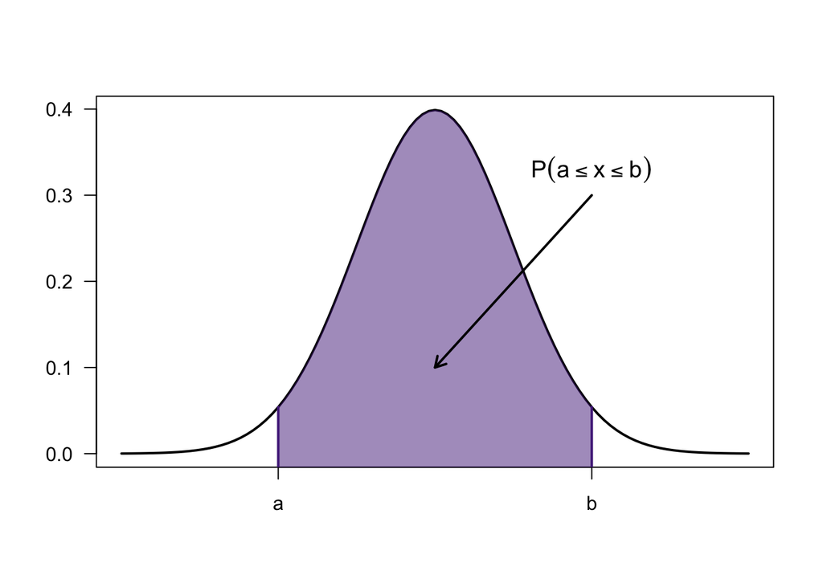

For a continuous r.v., probability is now “area under the curve”

- Only **intervals** will have *non-zero* probability
- Any single value will have a probability of **zero**:

$$P(X=a)=0, \ \text{for any single number} \ a$$

$$P(X=b)=0, \ \text{for any single number} \ b$$

- There’s also no difference between $\leq$ and $<$

$$P(X \leq 1)=P(X<1)$$

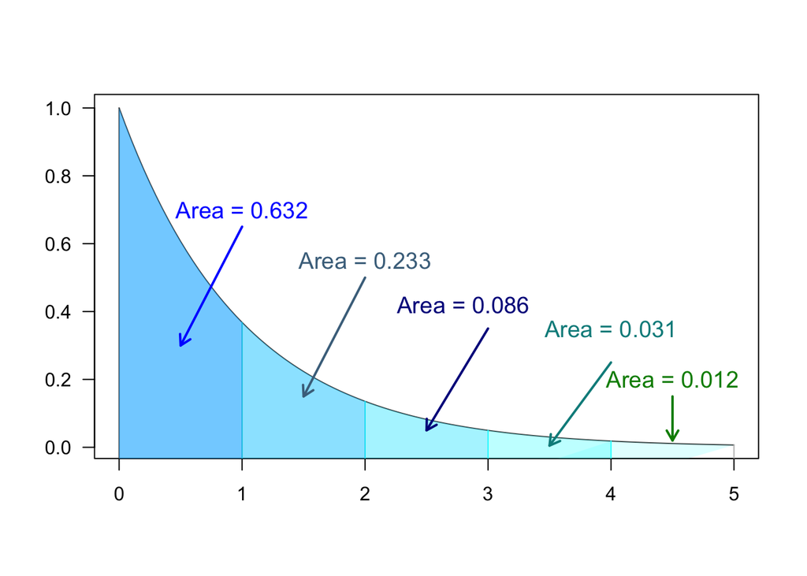

- This area, if known, can be used to make calculations on the probability of any given **interval** of outcomes in a continuous **PDF**

If every possible value of $X$ is equally likely then it takes on a **uniform distribution**